# MM9

2023-12-02

# MM9

## 1.

We find the number of students and teachers by counting unique observations for each

```r
satData %>% group_by(studid) %>% count() %>% nrow() # 122 students
```

```
## [1] 122
```

```r
satData %>% group_by(tchrid) %>% count() %>% nrow() # 12 teachers
```

```
## [1] 12
```

And also count the mean number of tests per student

```r
satData %>% group_by(studid) %>% count() %>% ungroup() %>% summarise(mean(n))
```

```
## # A tibble: 1 × 1
##   `mean(n)`
##       <dbl>
## 1      1.92
```

Meaning a little under two tests are taken per kid.

Consider the below cross-tabulation

```r
table(satData$tchrid, satData$year)
```

```
##
##         -1  0  1
##   14405  0  0 16
##   14433 26  0  0
##   14443 26  0  0
##   14453 27  0  0
##   14473  5  0  0
##   14484  0 27  0
##   14494  0 29  0
##   14523  1  0  0
##   14545  0  0 20
##   14575  0  0  9
##   14694  0 27  0
##   14755  0  0 21
```

This shows two things. That teachers only taught one grade at a time and that the number of students they have vary considerably.

We make a factor diagram with studentid, teacherid and year

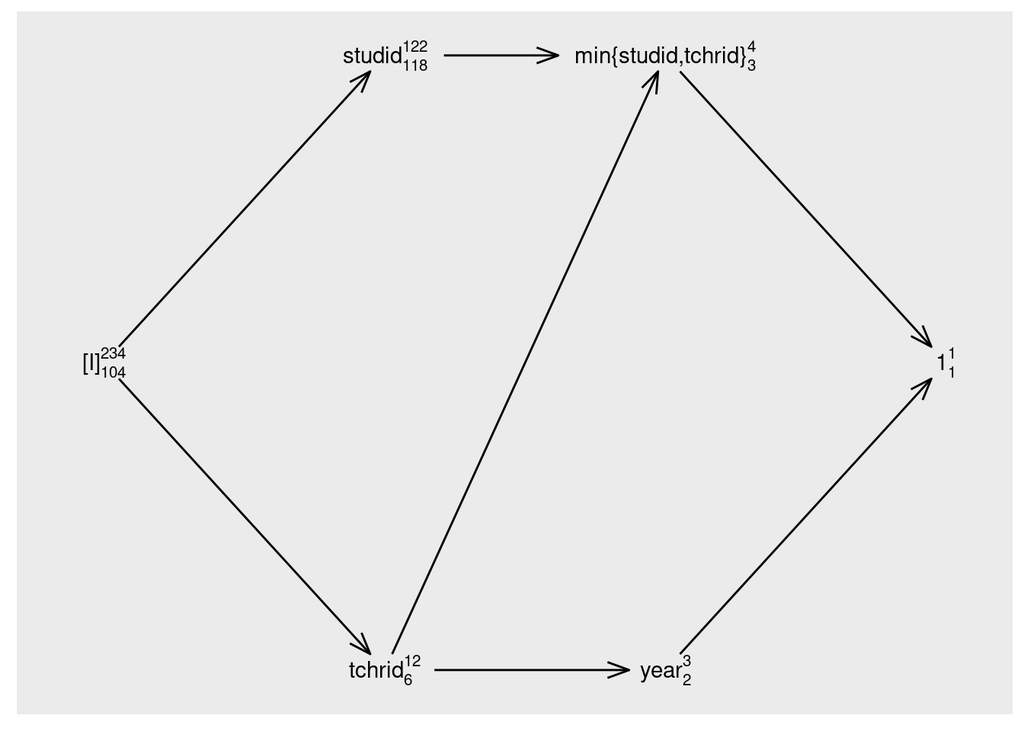

```r
plot(DD(~studid+tchrid + year,  data = satData))
```

## 2.

We want to see progression over time of the score. However, we still have to control for the fact that kids are different and that they are taught by different teachers. Not doing this will make it harder to detect the effect of progression. We do not want to say anything about the specific students/teachers, but about an average progression. This in combination with the fact that students/teachers are sampled from the overall population of students and teachers makes it most natural to consider these effects as random.

## 3.

We fit a model with random effects of student and teacher and fixed effect year, with year as a factor

```r
mod <- lmer(math ~ year + (1|tchrid) + (1|studid), data = satData)
summary(mod)
```

```
## Linear mixed model fit by REML ['lmerMod']
## Formula: math ~ year + (1 | tchrid) + (1 | studid)
##    Data: satData
##
## REML criterion at convergence: 2114
##
## Scaled residuals:
##      Min       1Q   Median       3Q      Max
## -2.08775 -0.52538 -0.06707  0.44512  2.84587
##
## Random effects:
##  Groups   Name        Variance Std.Dev.
##  studid   (Intercept) 336.8    18.35
##  tchrid   (Intercept) 829.7    28.80
##  Residual             238.5    15.44
## Number of obs: 234, groups:  studid, 122; tchrid, 12
##
## Fixed effects:
##             Estimate Std. Error t value
## (Intercept)   564.56      13.73  41.107
## year0          43.21      21.63   1.998
## year1          57.95      20.04   2.892
##
## Correlation of Fixed Effects:
##       (Intr) year0
## year0 -0.628
## year1 -0.680  0.433
```

We see that the estimated expected scores are 564.56, 564.56+43.21, 564.56+57.95 for grade 3, 4 and 5 respectively. The associated standard errors are 13.73, 21.63 and 20.04 respectively.

The parameter estimates that there could be improvement across years. We can get a better feeling for this by computing some confidence intervals

```r
mod %>% confint()
```

```
## Computing profile confidence intervals ...
```

```
##                  2.5 %    97.5 %
## .sig01       14.971174  22.33855
## .sig02       15.418546  40.34212
## .sigma       13.549163  17.75711
## (Intercept) 539.359465 589.70191
## year0         3.836916  82.82042
## year1        21.455091  94.63575
```

We see that none of the confidence intervals for year cover 0, again indicating that there is some improvement. We can also do a formal hypothesis test by dropping the year factor

```r
drop1(mod, test = "Chisq")
```

```
## Single term deletions
##
## Model:
## math ~ year + (1 | tchrid) + (1 | studid)
##        npar    AIC    LRT Pr(Chi)
## <none>      2147.2
## year      2 2151.9 8.6986 0.01292 *
## ---
## Signif. codes:  0 '***' 0.001 '**' 0.01 '*' 0.05 '.' 0.1 ' ' 1
```

Which indicates significance at a 5% level.

To answer whether it is reasonable to assume that students improve as much from 3rd to 4th grade as they do from 4th to 5th grade, we can do two things.

1. Reparameterize the model, to have 4th grade as the reference group. Consider the difference between the absolute value of the parameters correponding to 3rd and 5th grade as these are now measures of improvement relative to 4th grade. Compute a confidence interval for
   $$|\beta_5| - |\beta_3|$$
   Most likely by bootstrapping, and check if 0 is covered by this. Alternatively do a hypothesis test based on the bootstrap.
2. A more informal way of doing the above is to just reparametrize the model and check if there is overlap between the two confidence intervals.

```r
satData_mod <- satData
satData_mod$year <- factor(satData_mod$year, levels = c("0","-1","1"))
mod_contr <- lmer(math ~ year + (1|tchrid) + (1|studid), data = satData_mod)
mod_contr %>% confint()
```

```
## Computing profile confidence intervals ...
```

```
##                 2.5 %    97.5 %
## .sig01       14.97117  22.33855
## .sig02       15.41855  40.34212
## .sigma       13.54916  17.75711
## (Intercept) 577.15334 638.41169
## year-1      -82.82042  -3.83692
## year1       -25.72573  55.19119
```

## 4.

Estimated std.dev/variance for observations in study is
$$\sigma_{tot} = 18.35 + 28.80 + 15.44 = 62.59 \Rightarrow V(Y_i) =
62.59^2$$
Estimated correlation between observations from same student from different years
$$\frac{18.352^2}{V(Y_i)} = 0.08597$$

Estimtated correlation from same teacher
$$\frac{28.805^2}{V(Y_i)} = 0.2118$$
# MM 10

## 1.

We fit the same model as above with both REML and ML

```r
mod_REML <- lmer(math ~ year + (1|tchrid) + (1|studid), data = satData)
mod_ML <- lmer(math ~ year + (1|tchrid) + (1|studid), data = satData, REML = FALSE)
```

```r
summary(mod_REML)
```

```
## Linear mixed model fit by REML ['lmerMod']
## Formula: math ~ year + (1 | tchrid) + (1 | studid)
##    Data: satData
##
## REML criterion at convergence: 2114
##
## Scaled residuals:
##      Min       1Q   Median       3Q      Max
## -2.08775 -0.52538 -0.06707  0.44512  2.84587
##
## Random effects:
##  Groups   Name        Variance Std.Dev.
##  studid   (Intercept) 336.8    18.35
##  tchrid   (Intercept) 829.7    28.80
##  Residual             238.5    15.44
## Number of obs: 234, groups:  studid, 122; tchrid, 12
##
## Fixed effects:
##             Estimate Std. Error t value
## (Intercept)   564.56      13.73  41.107
## year0          43.21      21.63   1.998
## year1          57.95      20.04   2.892
##
## Correlation of Fixed Effects:
##       (Intr) year0
## year0 -0.628
## year1 -0.680  0.433
```

```r
summary(mod_ML)
```

```
## Linear mixed model fit by maximum likelihood  ['lmerMod']
## Formula: math ~ year + (1 | tchrid) + (1 | studid)
##    Data: satData
##
##      AIC      BIC   logLik deviance df.resid
##   2147.2   2167.9  -1067.6   2135.2      228
##
## Scaled residuals:
##      Min       1Q   Median       3Q      Max
## -2.09164 -0.51623 -0.06619  0.44760  2.82829
##
## Random effects:
##  Groups   Name        Variance Std.Dev.
##  studid   (Intercept) 340.1    18.44
##  tchrid   (Intercept) 576.6    24.01
##  Residual             238.0    15.43
## Number of obs: 234, groups:  studid, 122; tchrid, 12
##
## Fixed effects:
##             Estimate Std. Error t value
## (Intercept)   565.96      11.67  48.491
## year0          41.70      18.19   2.293
## year1          56.53      16.90   3.344
##
## Correlation of Fixed Effects:
##       (Intr) year0
## year0 -0.632
## year1 -0.682  0.440
```

The difference in both estimates and std. errors is negligable in this case. The std. errors are a bit lower for the ML approach.

# 2.

We conduct a simulation study to check whether the ML and REML estimators for the standard deviations are biased. We choose the ML model as the simulation model

```r
# Simulate n = 2000 datasets
data_sets <- simulate(mod_ML, 2000)
satData_copy <- satData

get_sd_estim <- function(dataset){
  #Update response
  satData_copy$math <- dataset

  #Fit models
  mod_REML <- lmer(math ~ year + (1|tchrid) + (1|studid), data = satData_copy)
  mod_ML <- lmer(math ~ year + (1|tchrid) + (1|studid), data = satData_copy, REML = FALSE)

  # Get dataframes for params
  reml <- VarCorr(mod_REML) %>% data.frame() %>%  tibble() %>%
    select(grp, sdcor) %>% mutate(type = "REML")
  ml <- VarCorr(mod_ML) %>% data.frame() %>%  tibble() %>%
    select(grp, sdcor) %>% mutate(type = "ML")

  return(bind_rows(reml,ml))

}
res <- lapply(data_sets, get_sd_estim) %>% bind_rows()
```

```
## boundary (singular) fit: see help('isSingular')
## boundary (singular) fit: see help('isSingular')
## boundary (singular) fit: see help('isSingular')
```

Let us first see if the estimators are biased

```r
estims <- res %>% group_by(grp, type) %>% summarise(estim = mean(sdcor))
```

[output not shown]

```r
parms <- VarCorr(mod_ML) %>% data.frame() %>% tibble() %>% select(grp, sdcor) %>% rename(true = "sdcor")
compare <- left_join(estims, parms) %>% mutate(abs_dev = abs(estim-true))
compare
```

```
## # A tibble: 6 × 5
## # Groups:   grp [3]
##   grp      type  estim  true abs_dev
##   <chr>    <chr> <dbl> <dbl>   <dbl>
## 1 Residual ML     15.4  15.4  0.0136
## 2 Residual REML   15.4  15.4  0.0157
## 3 studid   ML     18.4  18.4  0.0880
## 4 studid   REML   18.4  18.4  0.0910
## 5 tchrid   ML     19.8  24.0  4.24
## 6 tchrid   REML   23.3  24.0  0.694
```

The estimates look fairl unbiased except for teacher id which is biased for both and especially for ML.

Let us look at the estimator distribution

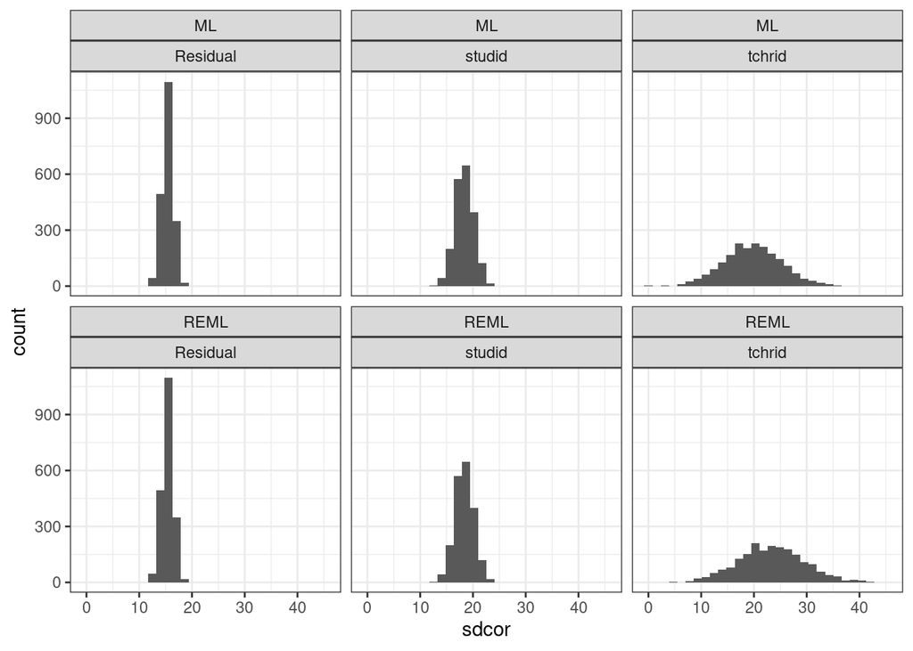

```r
res %>% ggplot(aes(x = sdcor)) + geom_histogram() + facet_wrap(~type+grp) + theme_bw()
```

They do look somewhat normal but the teacherid one is fcking heavytailed.

# 3.

We check the coverage of confidence intervals of parameters using the same simulation routine as above

```r
ML_param <- mod_ML %>% fixef()
REML_param <- mod_REML %>% fixef()

get_coverage_estim <- function(dataset){
  #Update response
  satData_copy$math <- dataset

  #Fit models
  mod_REML <- lmer(math ~ year + (1|tchrid) + (1|studid), data = satData_copy)
  mod_ML <- lmer(math ~ year + (1|tchrid) + (1|studid), data = satData_copy, REML = FALSE)

  #Check contained in confidence intervals
  ml_confint <- confint(mod_ML, method = "Wald")
  ml_low <- ml_confint[,1][names(ML_param)] <= ML_param
  ml_high <- ml_confint[,2][names(ML_param)] >= ML_param

  reml_confint <- confint(mod_REML, method = "Wald")
  reml_low <- reml_confint[,1][names(ML_param)] <= ML_param
  reml_high <- reml_confint[,2][names(ML_param)] >= ML_param

  ml_res <- ml_low*ml_high
  reml_res <- reml_low*reml_high

  df_ml <- tibble(covers = ml_res, parameter = names(ml_res), type = "ML")
  df_reml <- tibble(covers = reml_res, parameter = names(reml_res), type = "REML")

  return(bind_rows(df_ml, df_reml))
}
cov_res <- lapply(data_sets, get_coverage_estim) %>% bind_rows()
```

```
## boundary (singular) fit: see help('isSingular')
## boundary (singular) fit: see help('isSingular')
## boundary (singular) fit: see help('isSingular')
```

```r
#compute the coverage
estim_cov <- cov_res %>% group_by(type,parameter) %>% summarize(coverage = mean(covers))
estim_cov
```

```
## # A tibble: 6 × 3
## # Groups:   type [2]
##   type  parameter   coverage
##   <chr> <chr>          <dbl>
## 1 ML    (Intercept)    0.868
## 2 ML    year0          0.868
## 3 ML    year1          0.878
## 4 REML  (Intercept)    0.915
## 5 REML  year0          0.919
## 6 REML  year1          0.926
```

Which is a horrible coverage and much lower than the claimed 95%.